# Econometrics in R

Josh

2/28/2020

## Purpose

The purpose of this file is to showcase my skill set in sourcing, processing/cleaning, and analyzing data within R. Previously this empirical analysis was a semester long assignment for my Seminar in Public Policy at the University of Virginia. This has grown into a personal project now. Instead of using STATA like most economists, I used R to complete the following analysis and have been working to optimize my model and find additional data sources to better understand the relationship between the response variable and variables of interest. This code is incomplete as I translate over from STATA.

This project is incomplete but will be updated periodically as progress is made.

## Abstract

The low-income housing tax credit (LIHTC) program has produced and rehabilitated approximately 3 million rental units for low-income households since it was passed in 1986. It has become the largest and fastest growing federal housing assistance program in the United States. This analysis estimates the impact of low-income housing developments on local eviction rates in the United States from 2000 to 2016. Using the panel structure of the data, several different models are implemented.

## Importing Libraries and Setting Up Analysis

```r
knitr::opts_chunk$set(echo = TRUE)

# Install Packages
#install.packages("tidyverse","jsonlite","aws.s3","foreign","data.table","purrr","corrplot")

# Load Packages
library(readxl)
library(tidyverse)
library(jsonlite)
library(aws.s3)
library(foreign)
library(data.table)
library(purrr)
library(corrplot)
library(prettydoc)
path <- "C:\\Users\\RB232BZ\\OneDrive - EY\\Desktop\\Portfolio\\Project\\Data\\"
```

## Loading Data

I am using several different data sources. They include the following:

### Eviction data

This data is the number of evictions per tract (also includes common demographic and housing cost statistics at the tract-level). It was obtained from the Eviction Lab led by Matthew Desmond.

```r
#load eviction data from AWS api
usercsvobj <-get_object("s3://eviction-lab-data-downloads/NY/tracts.csv")
csvcharobj <- rawToChar(usercsvobj)
con <- textConnection(csvcharobj)
evictions_state <- read.csv(con,header= TRUE,colClasses= c(GEOID = "character", name = "character"))
close(con)
rm(csvcharobj,usercsvobj,con)

states <- c(state.abb, "DC")
evictions_usa <- evictions_state[0,]

#For loop to loop through the different states
for (i in states){
  url <- paste("s3://eviction-lab-data-downloads/",i,"/tracts.csv",sep="")
  usercsvobj <- get_object(url)
  csvcharobj <- rawToChar(usercsvobj)
  con <- textConnection(csvcharobj)
  evictions_state <- read.csv(con,header= TRUE,colClasses= c(GEOID = "character", name = "character"))
  close(con)
  evictions_usa <- bind_rows(evictions_usa,evictions_state)
}
rm(con, i,csvcharobj,usercsvobj,url,states,evictions_state)
evictions_usa <- evictions_usa %>% separate(parent.location,c("county","state"),sep = ", ")
head(evictions_usa)
```

```
##         GEOID year name         county   state population poverty.rate
## 1 01001020100 2000  201 Autauga County Alabama    1920.02        12.68
## 2 01001020100 2001  201 Autauga County Alabama    1920.02        12.68
## 3 01001020100 2002  201 Autauga County Alabama    1920.02        12.68
## 4 01001020100 2003  201 Autauga County Alabama    1920.02        12.68
## 5 01001020100 2004  201 Autauga County Alabama    1920.02        12.68
## 6 01001020100 2005  201 Autauga County Alabama    1789.09         5.38
##   renter.occupied.households pct.renter.occupied median.gross.rent
## 1                        158               23.37               442
## 2                        158               23.37               442
## 3                        158               23.37               442
## 4                        158               23.37               442
## 5                        157               23.37               442
## 6                        157               18.59               813
##   median.household.income median.property.value rent.burden pct.white pct.af.am
```

[output cut: 27 more lines]

### Qualified Census Tract data

This data contains the different qualified census tracts per year as outlined by the Department of Housing and Urban Development. The tracts that are given QCT status change over time as income and overall poverty rates change.

```r
##### Qualified Census Tract (QCT) Status Data #####

#load first DBF file
DBF2016 <- read.dbf(paste0(path,"QCT2016.DBF"))
DBF2016$FIPS <- DBF2016$FIPS %>% as.character()
DBF2016$year <- 0

#create empty qct data frame to house all the different DBF files
qct <- DBF2016[0,8:9]

#create for loop to read and append qct data frame with each piece of data
for (i in 2000:2016){
  if (i < 2002){
    file <- paste0(path, "QCT",as.character(i),".DBF",sep="")
    df <- read.dbf(file)
    df$year <- i
    df <- df %>% select(GEOCDAV,year)
    colnames(df) <- c("FIPS","year")
    df$FIPS <- df$FIPS %>% as.character()
    qct <- bind_rows(qct,df)
  }
  else{
    file <- paste0(path, "QCT", as.character(i),".DBF",sep="")
    df <- read.dbf(file)
    df$year <- i
    df <- df %>% select(FIPS,year)
    df$FIPS <- df$FIPS %>% as.character()
    qct <- bind_rows(qct,df)
  }
}
rm(i,df,file,DBF2016)

qct$FIPS <- unlist(lapply(as.vector(qct$FIPS),gsub,pattern=".",replacement="",fixed=TRUE))
for (i in 1:nrow(qct)){
  if ((str_length(qct[i,1]) == 10) == TRUE) {
    qct[i,1] <- paste("0",qct[i,1], sep = "")
  }
}
rm(i)
qct$qct <- 1


head(qct)
```

```
##          FIPS year qct
## 1 01001021000 2000   1
## 2 01003010600 2000   1
## 3 01011952100 2000   1
## 4 01013953100 2000   1
## 5 01013953400 2000   1
## 6 01015000300 2000   1
```

### HUD LIHTC data

This data set contains the description and information on different housing units built/upgraded through the LIHTC program.

```r
#Low-Income Housing Tax Credit (LIHTC) Properties
lihtc_json <- fromJSON("https://opendata.arcgis.com/datasets/907edabaf7974f7fb59beef14c4b82f6_0.geojson")
lihtc <- lihtc_json$features$properties %>% as.data.frame()

rm(lihtc_json)

head(lihtc)
```

```
##   OBJECTID      HUD_ID                            PROJECT           PROJ_ADD
## 1        1 AKA0000X003              EAGLE RIDGE TOWNHOMES   1775 NORTH THUMA
## 2        2 AKA0000X018 GATEWAY-SEWARD ASSOCIATES, LTD PTN  1810 PHOENIX ROAD
## 3        3 AKA0000X022     JUNEAU AFFORDABLE RENTALS, LLC     SCATTERED SITE
## 4        4 AKA0000X024            MILL BAY TOWNHOMES, LLC 1223 MILL BAY ROAD
## 5        5 AKA0000X030               TURNAGAIN PLACE APTS      2708 COHO WAY
## 6        6 AKA0000X031                 VISTA ROSE PHASE I  1250 N LUCILLE ST
##    PROJ_CTY PROJ_ST PROJ_ZIP STATE_ID                  CONTACT
## 1    PALMER      AK    99645 AK-05-23 EAGLE RIDGE OF PALMER LP
## 2    SEWARD      AK    99664 AK-99-99           DAVID J CORDES
## 3    JUNEAU      AK    99801 AK-99-99             ASHLEY DAVIS
## 4    KODIAK      AK    99615 AK-99-99                     <NA>
## 5 ANCHORAGE      AK    99517 AK-99-99                     <NA>
## 6   WASILLA      AK    99654 AK-99-99                     <NA>
##                                    COMPANY                       CO_ADD
```

[output cut: 104 more lines]

### HUD Section 8 voucher program data

This data is on the amount of $ allocated to the voucher program and its use over time.

```r
#Section 8 Vouchers
vouchers <- read_csv(paste0(path,"Housing_Choice_Vouchers_by_Tract.csv"))
#save data to reuse later
save(evictions_usa,lihtc,qct,vouchers, file=paste0(path,"housing_data.RData"))

head(vouchers)
```

```
## # A tibble: 6 x 12
##   OBJECTID GEOID STATE COUNTY TRACT EACODE EANAME HCV_PUBLIC HCV_PCT_RENTER_~
##      <dbl> <chr> <lgl> <lgl>  <lgl>  <dbl> <chr>       <dbl>            <dbl>
## 1        1 0401~ NA    NA     NA       128 Phoen~         35             3.87
## 2        2 0401~ NA    NA     NA       128 Phoen~         NA            NA
## 3        3 0401~ NA    NA     NA       128 Phoen~         48             8.16
## 4        4 0401~ NA    NA     NA       128 Phoen~         NA            NA
## 5        5 0401~ NA    NA     NA       128 Phoen~         NA            NA
## 6        6 0401~ NA    NA     NA       128 Phoen~         NA            NA
## # ... with 3 more variables: HCV_PUBLIC_PCT <dbl>, SHAPE_Length <dbl>,
## #   SHAPE_Area <dbl>
```

## Data Wrangling

Cleaning the data: The main challenge here is that the LIHTC database provided by the HUD does not provide a panel view. I need to create a column with the number of new LIHTC units per year and the cumulative number of units over time per census tract to match the structure of the eviction data set.

### Clean the LIHTC data

```r
#drop unnecessary columns from lihtc data
lihtc <- lihtc %>% mutate(PROJ_ADD = paste(PROJ_ADD,PROJ_CTY,PROJ_ST,PROJ_ZIP,sep=" ")) %>% select(HUD_ID, PROJECT, PROJ_ADD, ALLOCAMT, N_UNITS, LI_UNITS, INC_CEIL, LOW_CEIL, CEILUNIT, YR_PIS, YR_ALLOC, TRGT_POP, TRGT_FAM, TRGT_ELD, TRGT_DIS, TRGT_HML, TRGT_OTHER, TRGT_SPC, TYPE, CREDIT, N_UNITSR, LI_UNITR,TRACT_LEVEL)

#filter out lihtc units that do not have "year placed in service"  or tract-level
lihtc <- lihtc %>% filter(YR_PIS != "9999") %>% filter(YR_PIS != "8888") %>% filter(!is.na(TRACT_LEVEL))

# Sum up all the LIHTC units in a tract per year (years that have new or upgrades lihtc units)
lihtc_summed <- lihtc %>% select(TRACT_LEVEL,YR_PIS, N_UNITS, LI_UNITS) %>% group_by(TRACT_LEVEL,YR_PIS) %>% summarise_each(funs(sum)) %>% ungroup(TRACT_LEVEL,YR_PIS)
#previously used a function that looped through the entire eviction dataset and checked to see if there were lihtc units that matched year and tract id. Then I would append a vector with either 0 or the sum if it existed. Even after trying to utilize parallel computing, it took about an hour to run so below is my much faster way to complete what I wanted.

#create a dataframe that has every tract ID that I care about
tract <- evictions_usa$GEOID %>% unique() %>% as.vector()

#create a dataframe with the years between 1987 (the first year a LIHTC unit was placed in service) and 2000. This is because I want to have a cumulative sum
years <- 1987:2000

#create empty matrix, convert to a data frame and then reshape it (wide to long format) using gather
tract_year <- data.frame(matrix(ncol=length(years)+1,nrow=length(tract)))
colnames(tract_year) <- c(years,"GEOID")
tract_year$GEOID <- tract
tract_year <- tract_year %>% mutate(count=1)
tract_year <- gather(tract_year, "1987", "1988", "1989", "1990", "1991", "1992", "1993", '1994', '1995', '1996', '1997', '1998', '1999', '2000', key="year",value="count") %>% select(-count)

#join empty dataframe with the data with number of lihtc units per year for each tract
pre2000 <- tract_year %>% left_join(lihtc_summed,by=c("GEOID"="TRACT_LEVEL","year"="YR_PIS"))

#group by GEOID to get a cumulative sum of the lihtc units created from 1987 to 2000
year2000 <- pre2000 %>% select(-year) %>% group_by(GEOID) %>% summarize_each(funs(sum(.,na.rm = TRUE))) %>% mutate(year=2000)
#rename the columns
colnames(year2000) <- c("GEOID","cum_n_units","cum_li_units","year")

#clean the environment
rm(pre2000,tract,years,tract_year)
```

### Join data

Joining the other data frames together to make a single panel data set.

```r
#Load file if starting this section new
#load(file = "C:/Users/RB232BZ/OneDrive - EY/Desktop/Portfolio/Project/Data/housing_data.RData")

#create a new dataframe to work with
df <- evictions_usa

#join eviction data with qct data
df <- df %>% left_join(qct,by=c("GEOID"="FIPS","year")) %>% mutate(qct=ifelse(is.na(qct)==TRUE,0,qct))

#join lihtc data (new LIHTC units every year)
df$year <- df$year %>% as.character()
df <- df %>% left_join(lihtc_summed,by=c("GEOID"="TRACT_LEVEL","year"="YR_PIS"))
df <- df %>% mutate(N_UNITS = ifelse(is.na(N_UNITS)==TRUE,0,N_UNITS), LI_UNITS = ifelse(is.na(LI_UNITS)==TRUE,0,LI_UNITS))

#join lihtc data (the cumulative number of units over time)
df$year <- df$year %>% as.numeric()
df <- df %>% left_join(year2000,by=c("GEOID"="GEOID","year"="year"))
#replace NAs with previous the number of units added each year (whether 0 or some # using the previous 2 columns)
df <- df %>% mutate(cum_n_units = ifelse(is.na(cum_n_units)==TRUE,N_UNITS,cum_n_units), cum_li_units = ifelse(is.na(cum_li_units)==TRUE,LI_UNITS,cum_li_units))
#calculate cumulative sum using group by and cumsum function
final_df <- df %>% group_by(GEOID) %>% mutate(cum_n_units = cumsum(cum_n_units), cum_li_units = cumsum(cum_li_units))


final_df  <- final_df %>% select(-c("name","low.flag","imputed","subbed"))

#clean the environment
rm(year2000,lihtc_summed)

head(final_df)
```

```
## # A tibble: 6 x 29
## # Groups:   GEOID [1]
##   GEOID  year county state population poverty.rate renter.occupied~
##   <chr> <dbl> <chr>  <chr>      <dbl>        <dbl>            <dbl>
## 1 0100~  2000 Autau~ Alab~      1920.        12.7               158
## 2 0100~  2001 Autau~ Alab~      1920.        12.7               158
## 3 0100~  2002 Autau~ Alab~      1920.        12.7               158
## 4 0100~  2003 Autau~ Alab~      1920.        12.7               158
## 5 0100~  2004 Autau~ Alab~      1920.        12.7               157
## 6 0100~  2005 Autau~ Alab~      1789.         5.38              157
## # ... with 22 more variables: pct.renter.occupied <dbl>,
## #   median.gross.rent <dbl>, median.household.income <dbl>,
## #   median.property.value <dbl>, rent.burden <dbl>, pct.white <dbl>,
## #   pct.af.am <dbl>, pct.hispanic <dbl>, pct.am.ind <dbl>, pct.asian <dbl>,
## #   pct.nh.pi <dbl>, pct.multiple <dbl>, pct.other <dbl>,
## #   eviction.filings <dbl>, evictions <dbl>, eviction.rate <dbl>,
## #   eviction.filing.rate <dbl>, qct <dbl>, N_UNITS <dbl>, LI_UNITS <dbl>,
## #   cum_n_units <dbl>, cum_li_units <dbl>
```

### Additional data cleaning

#### Checking Missing Data

First thing to check for is missing data.

```r
#check what data is missing
NAcol <- which(colSums(is.na(final_df)) > 0)
sort(colSums(sapply(final_df[NAcol], is.na)), decreasing = TRUE)
```

```
##                  evictions              eviction.rate
##                     269057                     269057
##       eviction.filing.rate           eviction.filings
##                     250956                     250948
##          median.gross.rent      median.property.value
##                      13770                      13508
##                rent.burden    median.household.income
##                      10907                       7056
##                 population               poverty.rate
##                        147                        147
##        pct.renter.occupied                  pct.white
##                        147                        147
##                  pct.af.am               pct.hispanic
##                        147                        147
##                 pct.am.ind                  pct.asian
##                        147                        147
##                  pct.nh.pi               pct.multiple
##                        147                        147
##                  pct.other renter.occupied.households
##                        147                        126
##                      state
##                         17
```

Here we can see that there is a lot of missing eviction data. The eviction data comes from the Princeton Eviction Lab led by Matthew Desmond. He wrote the book “Evicted.” The methodology report that is available on its website highlights the fact that this data collection process was as thorough as they could complete it. However they could only collect what was available. The data that I am using here has already undergone some imputation methods to fill in missing records.

To summarize their imputation methodology: * Years before the first available year for data within a county were not included in our data. Likewise, years after the last available year of data within a county were excluded. One exception was made for data in 2016. If a county had available data for 2015 but was missing data in 2016, we pulled the value from 2015 forward to estimate projected case volume in that county (N = 93). * When only one year of data was missing within a county between two years of valid data, the case volume was imputed using the average of the preceding and following years. When two consecutive years of data were missing, we linearly interpolated between the last known and reliable value and the next known and reliable value. * Counties had to have at least two consecutive years of valid data to be included. Counties that did not meet this requirement are shown as missing. In total, 171 counties are displayed as missing for all years. The counties and years marked as missing are displayed as “Unavailable” on the map * Four states – Alaska, Arkansas, South Dakota, and North Dakota – did not have consistent data coverage at any point in the 2000-2016 period. For these states, we substituted data on case volume from the state-reported court statistics, as discussed in Section II.2. No counties in these states were included in the imputation procedure.

I can either impute the missing eviction data or remove the counties that the Eviction Lab. Based on the extensive imputation work completed by the team I will remove observations from the data with missing eviction data (remove the 171 counties with missing data for all 17 years).

We see that approximately 1% or less of the observations are missing data for median gross rent, median property value, rent burden, median household income, etc.

#### Removing Observations with Missing Data

```r
final_df <- final_df %>% ungroup(GEOID)

#check which counties are missing the most data
#load eviction data at county level
usercsvobj <-get_object("s3://eviction-lab-data-downloads/NY/counties.csv")
csvcharobj <- rawToChar(usercsvobj)
con <- textConnection(csvcharobj)
evictions_state <- read.csv(con,header= TRUE,colClasses= c(GEOID = "character", name = "character"))
close(con)
rm(csvcharobj,usercsvobj,con)

states <- c(state.abb, "DC")
county_level <- evictions_state[0,]

#For loop to loop through the different states
for (i in states){
  url <- paste("s3://eviction-lab-data-downloads/",i,"/counties.csv",sep="")
  usercsvobj <- get_object(url)
  csvcharobj <- rawToChar(usercsvobj)
  con <- textConnection(csvcharobj)
  evictions_state <- read.csv(con,header= TRUE,colClasses= c(GEOID = "character", name = "character"))
  close(con)
  county_level <- bind_rows(county_level,evictions_state)
}
rm(con, i,csvcharobj,usercsvobj,url,states,evictions_state)

#create a data frame with the number of missing rows for each county and find the counties missing eviction data for every year in the panel data set
county_missing <- county_level %>% mutate(county_state = paste0(name,"-",parent.location)) %>% select(GEOID, county_state, evictions) %>% mutate(missing = ifelse(is.na(evictions),1,0)) %>% mutate(rows = 1) %>% group_by(GEOID, county_state) %>% summarize_each(list(sum)) %>%
  filter(is.na(evictions)) %>%
  filter(missing == rows)
#create a list with the new variable
missing_list <- county_missing$county_state

#remove counties missing a significant amount of eviction data
final_df <- final_df %>% mutate(county_state = paste0(county,"-",state)) %>% mutate(filter = ifelse(county_state %in% missing_list,1,0)) %>% filter(filter == 0) %>%
  select(-c("county_state","filter"))

#check what data is missing
NAcol <- which(colSums(is.na(final_df)) > 0)
sort(colSums(sapply(final_df[NAcol], is.na)), decreasing = TRUE)
```

```
##           eviction.filings                  evictions
##                     193620                     193620
##              eviction.rate       eviction.filing.rate
##                     193620                     193620
##      median.property.value          median.gross.rent
##                      12835                      12580
##                rent.burden    median.household.income
##                      10007                       6613
##                 population               poverty.rate
##                        142                        142
##        pct.renter.occupied                  pct.white
##                        142                        142
##                  pct.af.am               pct.hispanic
##                        142                        142
##                 pct.am.ind                  pct.asian
##                        142                        142
##                  pct.nh.pi               pct.multiple
##                        142                        142
##                  pct.other renter.occupied.households
##                        142                        126
##                      state
##                         17
```

After removing the 385 counties and independent cities, I only reduced the missing eviction data by 28.0% or 75,000 observations.

```r
#check which tracts are missing the most data
tract_missing <- final_df %>% select(GEOID, evictions) %>% mutate(count = ifelse(is.na(evictions),1,0)) %>% group_by(GEOID) %>% summarize_each(list(sum)) %>%
  filter(is.na(evictions)) %>% filter(count >= 9)

#create a list of tracts to remove
tract_missing <- tract_missing %>% select(GEOID)
tract_missing <- tract_missing$GEOID

#remove tracts missing 9 or more years of eviction data
final_df <- final_df %>% mutate(filter1 = ifelse(GEOID %in% tract_missing,1,0)) %>% filter(filter1 == 0) %>% select(-filter1)

#recheck what data is missing
NAcol <- which(colSums(is.na(final_df)) > 0)
sort(colSums(sapply(final_df[NAcol], is.na)), decreasing = TRUE)
```

```
##           eviction.filings                  evictions
##                      79588                      79588
##              eviction.rate       eviction.filing.rate
##                      79588                      79588
##          median.gross.rent      median.property.value
##                      10350                       9730
##                rent.burden    median.household.income
##                       8248                       5141
## renter.occupied.households                 population
##                        126                        118
##               poverty.rate        pct.renter.occupied
##                        118                        118
##                  pct.white                  pct.af.am
##                        118                        118
##               pct.hispanic                 pct.am.ind
##                        118                        118
##                  pct.asian                  pct.nh.pi
##                        118                        118
##               pct.multiple                  pct.other
##                        118                        118
```

#### Imputing Missing Data

```r
#create a new data frame
imputed_df <- final_df

# recalculate what data is left
tract_missing <- imputed_df %>% select(GEOID, evictions) %>% mutate(count = ifelse(is.na(evictions),1,0)) %>% group_by(GEOID) %>% summarize_each(list(sum)) %>%
  filter(is.na(evictions))

#assess how much data needs to be imputed
tract_missing %>% select(count) %>% mutate(count2=1) %>% group_by(count) %>% summarize_each(list(sum))
```

```
## # A tibble: 8 x 2
##   count count2
##   <dbl>  <dbl>
## 1     1  13851
## 2     2   5089
## 3     3   1334
## 4     4   1665
## 5     5   2343
## 6     6   2448
## 7     7   1666
## 8     8    854
```

At this point, there is still some missing data and I have not imputed any data.

#### Factorizing Variables

```r
#check what the data looks like again
glimpse(final_df)
```

```
## Rows: 992,096
## Columns: 29
## $ GEOID                      <chr> "01001020100", "01001020100", "010010201...
## $ year                       <dbl> 2000, 2001, 2002, 2003, 2004, 2005, 2006...
## $ county                     <chr> "Autauga County", "Autauga County", "Aut...
## $ state                      <chr> "Alabama", "Alabama", "Alabama", "Alabam...
## $ population                 <dbl> 1920.02, 1920.02, 1920.02, 1920.02, 1920...
## $ poverty.rate               <dbl> 12.68, 12.68, 12.68, 12.68, 12.68, 5.38,...
## $ renter.occupied.households <dbl> 158, 158, 158, 158, 157, 157, 157, 157, ...
## $ pct.renter.occupied        <dbl> 23.37, 23.37, 23.37, 23.37, 23.37, 18.59...
## $ median.gross.rent          <dbl> 442, 442, 442, 442, 442, 813, 813, 813, ...
## $ median.household.income    <dbl> 36685, 36685, 36685, 36685, 36685, 62159...
## $ median.property.value      <dbl> 88200, 88200, 88200, 88200, 88200, 12210...
## $ rent.burden                <dbl> 22.5, 22.5, 22.5, 22.5, 22.5, 27.0, 27.0...
## $ pct.white                  <dbl> 89.69, 89.69, 89.69, 89.69, 89.69, 78.88...
```

[output cut: 16 more lines]

#### Factorizing Variables

```r
final_df$GEOID <- final_df$GEOID %>% as.factor()
final_df$county <- final_df$county %>% as.factor()
final_df$state <- final_df$state %>% as.factor()
final_df$qct <- final_df$qct %>% as.factor()
```

## Exploratory Data Analysis

All character vectors are now converted into categorical

### Correlations

```r
numericVars <- which(sapply(final_df, is.numeric)) #index vector numeric variables
factorVars <- which(sapply(final_df, is.factor)) #index vector factor variables
```

There are 25 numeric variables, and 4 categoric variables

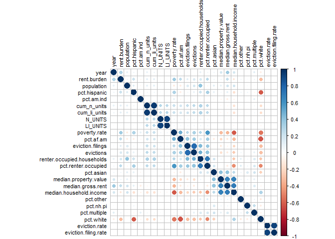

```r
all_numVar <- final_df[, numericVars]
cor_numVar <- cor(all_numVar, use="pairwise.complete.obs") #correlations of all numeric variables

corrplot(cor_numVar, order = "hclust",tl.col="black", tl.pos = "lt", tl.cex = 0.7,cl.cex = .7, number.cex=.7)
```